# Estimates of Wenatchee Steelhead Redds and Spawners

Spawn Year 2019

Kevin See<sup>1,✉</sup>

October 19, 2021

Abstract

This report contains estimates of total steelhead redds in the Wenatchee, after accounting for observer bias. It also includes estimates of spawners, as well as prespawn mortality.

<sup>1</sup> Biomark, Inc.

<sup>✉</sup> Correspondence: Kevin See <Kevin.See@merck.com>

# 1 Introduction

Redd counts are an established method to provide an index of adult spawners (Gallagher et al. 2007). In the Wenatchee subbasin, index reaches are surveyed weekly during the steelhead spawning season (Mar 11, 2019 - Jun 03, 2019) and non-index reaches are surveyed once during the peak spawning period. The goal of this work is to:

1. Predict observer net error, using the model described in Murdoch et al. (2018).
2. Use estimates of observer net error rates and the mean survey interval to estimate the number of redds in each index reach, using a Gaussian area under the curve (GAUC) technique described in Millar et al. (2012) and Murdoch et al. (2018).
3. Estimate the total number of redds in the non-index reaches by adjusting the observed counts with the estimated net error where possible.
4. Sum the total number of estimated redds for the entire Wenatchee subbasin.

# 2 Methods

## 2.1 Net Error Model

The net error ($NE$) for a reach $i$ is defined as

$$NE_i = \frac{F_i}{V_i}$$

where $F_i$ is the number of redds the surveyor reported and $V_i$ is the true number of redds in the reach. Therefore, if we have an estimate of net error ($\hat{NE_i}$), we can calcultate the true number of redds based on that estimqte and the number of redds the surveyor reported:

$$\begin{equation}
V_i = \frac{F_i}{\hat{NE_i}}
\tag{2.1}
\end{equation}$$

The model for observer net error is fully described in Murdoch et al. (2018). It uses covariates of the log of observer experience, mean discharge, the observed redd density and mean thalweg CV as a proxy for channel complexity. After normalizing these covariates, the model coefficients are shown in Table 2.1. The response, net error, is scaled such that estimates of net error less than 1 suggest more errors of omission, while estimates greater than 1 suggest more errors of commission. An estimate of net error equal to one would indicate the observed count equals the true number of redds.

Table 2.1: Net error model covariates and coefficients.

| Covariate | Estimate | Std. Error |
| --- | --- | --- |
| (Intercept) | 0.682 | 0.039 |
| Obs. Redd Density | 0.277 | 0.053 |
| Mean Thalweg CV | -0.169 | 0.043 |
| Mean Discharge | 0.116 | 0.048 |
| Log Surveyor Exp. | 0.115 | 0.042 |

## 2.2 Data

Redd counts were conducted on a nearly weekly basis for index reaches, and once during the peak spawning period for non-index reaches. The covariates in the observer error model of Murdoch et al. (2018) were collected during each survey. The covariate of mean thalweg CV was calculated based on all measurements taken within a reach across years (assuming this covariate does not vary through time within a reach). They were compared with the covariates contained in the model data set, as well as the estimates of net error (Figure 2.1).

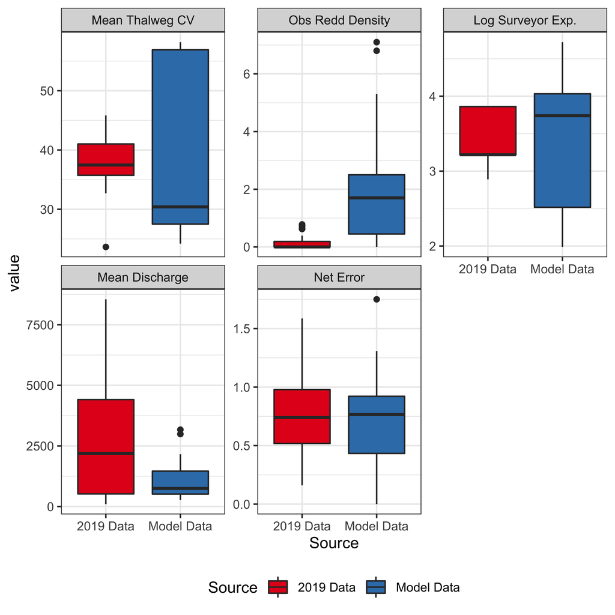

Figure 2.1: Net error covariate values from the original study the predicted reaches in this report.

Those covariates in the observer error model were collected during each survey in 2019, and predictions of net error were made for each survey. From these survey specific estimates of net error, a mean and standard error of net error was calculated for each reach. The standard deviation was calculated by taking the square root of the sum of the squared standard errors for all predictions within a reach.

## 2.3 Estimating Redds

Use of the GAUC methodology was limited to index reaches with a minimum of two redds and at least three weeks with at least one new redd found. For those reaches, we used the method described in Millar et al. (2012) and Murdoch et al. (2018). The GAUC model was developed with spawner counts in mind. As it is usually infeasible to mark every individual spawner, only total spawner counts can be used, and an estimate of average stream life must be utilized to translate total spawner days to total unique spawners. However, in adapting this for redd surveys, we note that individual redds can be marked, and therefore the GAUC model can be fit to new redds only. The equivalent of stream life thus the difference between survey numbers which can be fixed at 1. We applied the average net error from all the surveys when redds were visible, so as to not bias the estimate from early weeks when no redds were found, and the observed redd density was zero.

For non-index reaches, which were surveyed only once during peak spawning, the estimate of total redds was calculated by dividing the observed redds by the estimate of net error associated with that survey (Eq. (2.1)). This assumes that no redds were washed out before the non-index survey, and that no new redds appeared after that survey. As the number of redds observed in the non-index reaches ranged from 0 to 2, any violation of this assumption should not affect the overall estimates very much. Any index reaches that did not meet the thresholds described above were treated as non-index reaches, and the total observed redds in those reaches were divided by the mean estimate of net error for each reach.

When summing reach-scale estimates to obtain estimates at the stream scale, an attempt was made to incorporate the fact that the reaches within a stream are not independent. Estimates of correlation between the reaches within a stream were made based on weekly observed redds. This method may not be perfect, since spawners could use certain reaches preferentially at different times in the season, but it may be the best we can do. Because correlations are often quite high between reaches, this is a better alternative than to naively assume the standard errors between reaches are independent of one another. These correlation estimates were combined withestimates of standard error at the reach scale to calculate a covariance matrix for the reaches within each stream, which was used when summing estimates of total redds to estimate the standard error at the stream scale. Failure to incorporate the correlations between reaches would result in an underestimate of standard error at the stream scales. Different streams (and therefore reaches in different streams) were assumed to be independent.

## 2.4 Estimating Spawners

Esimates of escapement to various tributaries in the Wenatchee were made using a branching patch-occupancy model (Waterhouse et al. 2020) based on PIT tag observations of fish tagged at Priest Rapids dam. All fish that escaped to the various tributaries were assumed to be spawners (i.e. prespawn mortality only occurs in the mainstem). Reaches below the PIT tag arrays in some tributaries were surveyed for redds, but we assumed there was no observer error in those reaches.

To convert estimates of redds in mainstem areas into estimates of natural and hatchery spawners, the estimates of redds were multiplied by a fish per redd (FpR) estimate and then by the proportion of hatchery or wild fish. The fish per redd estimate was based on PIT tags from the branching patch-occupany model observed to move into the lower or upper Wenatchee (below or above Tumwater dam), but not into tributaries upstream of Tumwater. FpR was calculated as the ratio of male to female fish, plus 1. Reaches W1 - W7 are below Tumwater, while reaches W8 - W10 are above Tumwater. Similarly, the proportion of hatchery and natural origin fish was calculated from the same group of PIT tags for areas above and below Tumwater. For reaches in tributaries below the tributary PIT tag array, FpR and proportion hatchery were calculated based on observed PIT tags moving into the lower regions of each tributary.

## 2.5 Prespawn Mortality

After translating estimates of redds to estimates of spawners by origin, we can then compare the spawner estimates to escapement estimates made using PIT tags, and estimate a prespawn mortality rate. Taking the total PIT-tag based escapement estimate, by origin, to the Wenatchee, we then subtract any fish removed at Tumwater or Dryden for brookstock or surplus, as well as any deaths due to harvest (Table 2.2), and then subtract the total estimate of spawners, including the tributaries, to provide an estimate of how many fish succumbed to prespawn mortality. Dividing that number by the total escapement estimate provides an estimate of the prespawn mortality rate, by origin across the entire Wenatchee population.

Table 2.2: Known number of fish removed at dams or due to harvest, by origin.

| Source | Hatchery | Natural |
| --- | --- | --- |
| Dryden | 41 | 31 |
| Harvest | 0 | 0 |
| Tumwater | 26 | 26 |

We can also compare estimates of escapement to the mainstem lower Wenatchee (after subtracting the the fish removed at Dryden) and to the upper mainstem above Tumwater (after subtracting the fish removed at Tumwater) to total estimates of spawners in mainstem areas below and above Tumwater dam. This allows us to estimate prespawn mortality in the mainstem above and below Tumwater, by origin. Using this approach, it is unclear which area deaths due to harvest should apply to, which is a moot point in years when there was no harvest.

If any group had a higher estimates of spawners compared to escapement, we fixed our prespawn mortality estimate at 0, reflecting a very low level of prespawn mortality. There is uncertainty in both the escapement and spawner estimates, which could explain why these types of scenarios could arise.

# 3 Results

## 3.1 Redd estimates

The estimated net error, observed redds and estimates of redds at the reach scale are shown in Table 3.1. Plots of the new redds and the GAUC fit to those data are shown in Figure 3.1. The results are summarized by major areas and population scale in Table 3.2.

Table 3.1: Estimates of mean net error and redds for each reach.

River

Reach

Type

Net Error

Net Error CV

Observed Redds

Estimated Redds

Std. Err. Redds

Redds CV

Chiwawa

C1

Index

1

0

0

0

0

Nason

N1

Index

1

0

0

0

0

Peshastin

P1

Index

1

0

1

1

0

0

Wenatchee

W1

Non-Index

1

0

0

0

0

Wenatchee

W2

Index

1

0

0

0

0

Wenatchee

W3

Non-Index

1

0

0

0

0

Wenatchee

W4

Non-Index

1

0

0

0

0

Wenatchee

W5

Non-Index

1

0

0

0

0

Wenatchee

W6

Non-Index

1

0

0

0

0

Wenatchee

W6

Index

0.95

0.181

5

5

2.5

0.5

Wenatchee

W8

Non-Index

1

0

0

0

0

Wenatchee

W8

Index

0.727

0.203

1

1

0.3

0.279

Wenatchee

W9

Non-Index

0.916

0.185

1

1

0.2

0.202

Wenatchee

W9

Index

0.923

0.195

18

19

6.5

0.343

Wenatchee

W10

Non-Index

1

0

2

2

0

0

Wenatchee

W10

Index

0.709

0.186

25

35

9.6

0.273

Wenatchee

C1

Non-Index

1

0

0

0

0

Wenatchee

N1

Non-Index

1

0

0

0

0

Wenatchee

P1

Non-Index

1

0

1

1

0

0

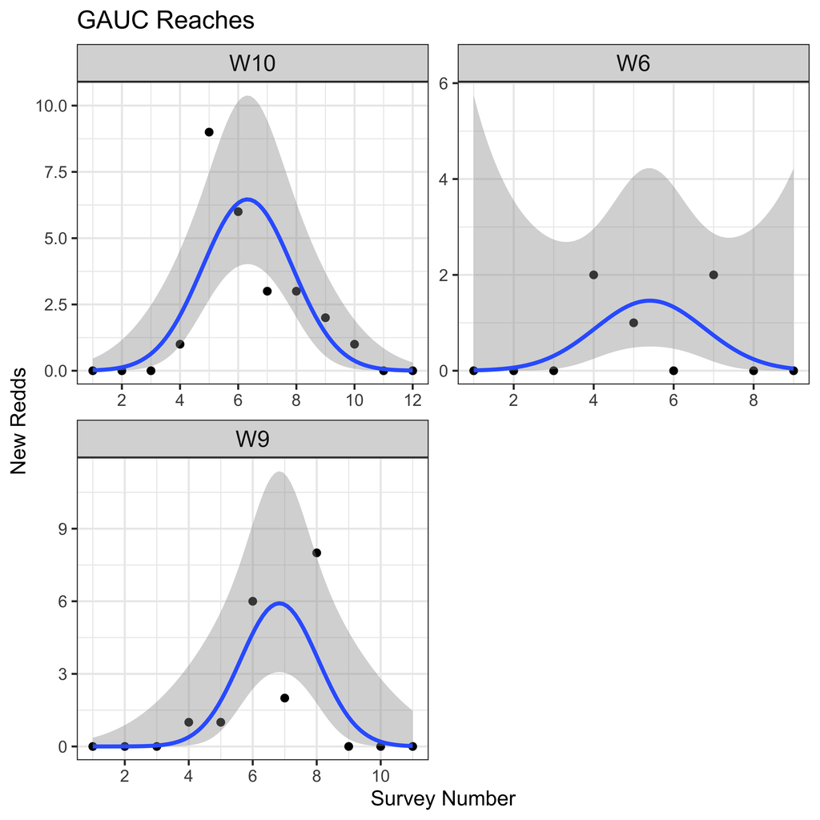

Figure 3.1: Plots of observed redd counts (black dots) through time for each qualifying index reach, and the fitted curve from the GAUC model (blue line) with associated uncertainty (gray).

Table 3.2: Estimate of redds in mainstem Wenatchee, above and below Tumwater Dam, and any tributaries surveyed.

River

Location

Index

# Reaches

Observed Redds

Estimated Redds

Std. Err. Redds

Redds CV

Chiwawa

Tributary

Y

1

0

0

0

Nason

Tributary

Y

1

0

0

0

Peshastin

Tributary

Y

1

1

1

0

0

Wenatchee

Mainstem Below Tumwater

N

5

0

0

0

Wenatchee

Mainstem Below Tumwater

Y

2

5

5

2.499

0.5

Wenatchee

Mainstem Above Tumwater

N

3

3

3

0.202

0.1

Wenatchee

Mainstem Above Tumwater

Y

3

44

55

11.588

0.2

Wenatchee

Tributary

N

3

1

1

0

0

Total

19

54

65

11.856

0.2

## 3.2 Spawner Estimates

Table 3.3: Number of PIT tags detected in each area by sex and origin.

| Location | Sex | Origin | n tags |
| --- | --- | --- | --- |
| Below TUM | F | H | 17 |
| Below TUM | F | W | 11 |
| Below TUM | M | H | 6 |
| Below TUM | M | W | 10 |
| TUM bb | F | H | 3 |
| TUM bb | F | W | 7 |
| TUM bb | M | H | 2 |
| TUM bb | M | W | 3 |
| Tribs above TUM | F | H | 10 |
| Tribs above TUM | F | W | 6 |
| Tribs above TUM | M | H | 7 |
| Tribs above TUM | M | W | 4 |
| Peshastin | F | H | 1 |
| Peshastin | F | W | 4 |
| Peshastin | M | W | 6 |
| Nason | F | H | 1 |
| Nason | M | H | 2 |
| Chiwawa | F | H | 6 |
| Chiwawa | M | H | 2 |

Parameter estimates for fish / redd and proportion hatchery based on this PIT tag data are shown in Table 3.4.

Table 3.4: Fish per redd and hatchery / natural origin proportion estimates.

| Area | Fish / redd | FpR Std. Error | Prop. Hatchery | Prop Std. Error |
| --- | --- | --- | --- | --- |
| Below TUM | 1.571 | 0.131 | 0.523 | 0.075 |
| Mainstem above TUM | 1.500 | 0.204 | 0.333 | 0.122 |
| Peshastin | 2.200 | 0.516 | 0.091 | 0.087 |
| Nason | 3.000 | 1.826 | 1.000 | 0.000 |
| Chiwawa | 1.333 | 0.215 | 1.000 | 0.000 |

Combining PIT tag-based estimates of spawners in the tributaries with adjusted redd-based estimates of spawners in the mainstem areas, Table 3.5 shows all of them, broken down by area and origin.

Table 3.5: Estimates (CV) of spawners by area and origin.

Area

Type

Natural

Hatchery

W1

Non-Index

0 (-)

0 (-)

W2

Index

0 (-)

0 (-)

W3

Non-Index

0 (-)

0 (-)

W4

Non-Index

0 (-)

0 (-)

W5

Non-Index

0 (-)

0 (-)

W6

Index

4 (0.53)

4 (0.53)

W6

Non-Index

0 (-)

0 (-)

W8

Index

1 (0.36)

1 (0.48)

W8

Non-Index

0 (-)

0 (-)

W9

Index

19 (0.41)

10 (0.52)

W9

Non-Index

1 (0.3)

1 (0.44)

W10

Index

35 (0.36)

18 (0.48)

W10

Non-Index

2 (0.23)

1 (0.39)

Icicle

Trib

12 (0.6)

25 (0.4)

P1

Non-Index

2 (0.25)

0 (0.98)

Peshastin

Trib

48 (0.31)

9 (0.68)

Mission

Trib

13 (0.61)

9 (0.74)

Chumstick

Trib

9 (0.77)

10 (0.76)

Chiwaukum

Trib

0 (-)

0 (-)

C1

Non-Index

0 (-)

0 (-)

Chiwawa

Trib

23 (0.4)

51 (0.31)

N1

Non-Index

0 (-)

0 (-)

Nason

Trib

16 (0.51)

17 (0.49)

Little Wenatchee

Trib

0 (-)

0 (-)

White River

Trib

0 (-)

0 (-)

Total

185 (0.15)

156 (0.16)

## 3.3 Prespawn Mortality

The estimates of overall prespawn mortality within the Wenatchee population, by origin, are shown in Table 3.6. The estimates of prespawn mortality in mainstem areas above and below Tumwater dam are displayed in Table 3.7.

Table 3.6: Wenatchee prespawn mortality estimates. Includes estimates (standard error) of escapement, spawners, prespawn mortality, and standard error of this rate, separated by origin.

Origin

Escapement

Spawners

Prespawn Mortality

SE

CV

Natural

133 (29)

185 (27)

0

Hatchery

143 (31)

0

Table 3.7: Mainstem Wenatchee prespawn mortality estimates. Includes estimates (standard error) of escapement, spawners, prespawn mortality, and the standard error of this rate, separated by origin and mainstem areas above and below Tumwater dam.

Origin

Area

Escapement

Spawners

Prespawn Mortality

SE

CV

Natural

Above Tumwater

19 (13)

58 (15)

0.000

Hatchery

Above Tumwater

1 (11)

29 (10)

0.000

Natural

Below Tumwater

0 (12)

4 (2)

0.000

Hatchery

Below Tumwater

22 (17)

4 (2)

0.813

0.177

0.217

# 4 Discussion

Most of the covariates collected in 2019 were within the range of those in the model data set from Murdoch et al. (2018), leading to estimates of net error in a very similar range to the model dataset (Figure 2.1). However, some reaches did not meet the minimum thresholds of number of observed redds or number of weeks with at least one new redd observed, so we used the GAUC method in only three reaches.

The estimates of high prespawn mortality in the lower mainstem of the Wenatchee for hatchery fish could be accurate, but it should be noted that many of the redd surveys failed to observe a single redd in many of the reaches (Table 3.1). Without any observed redds, any estimate of net error is moot, as the adjusted redd estimate will still be zero. So if all the redds were missed in some of those reaches, the estimate of total spawners in the lower mainstem should be higher, leading to a lower estimate of prespawn mortality. It is unclear whether that actually occurred, or if there were actually no redds this year in those reaches.

Some of the estimates of prespawn mortality were zero this year, due to higher estimates of spawners compared to escapement, at least after removals had been accounted for. In some cases, there were overlapping confidence intervals between spawners and escapement, so not too much should be made of that fact, and we interpret that as at least very low levels of prespawn mortality, perhaps even none.

# 5 Acknowledgements

The data for this report was collected by Washington Department of Fish and Wildlife. Development of the observer error model was done in collaboration with Andrew Murdoch, WDFW.

# 6 References

Gallagher, S. P., P. K. J. Hahn, and D. H. Johnson. 2007. Salmonid field protocols handbook: Techniques for assessing status and trends in salmon and trout populations. Pages 197–234 *in* D. H. Johnson, editor. American Fisheries Society, Bethesda, Maryland.

Millar, R. B., S. McKechnie, and C. E. Jordan. 2012. Simple estimators of salmonid escapement and its variance using a new area-under-the-curve method. Canadian Journal of Fisheries and Aquatic Sciences 69(6):1002–1015.

Murdoch, A. R., C. J. Herring, C. H. Frady, K. See, and C. E. Jordan. 2018. Estimating observer error and steelhead redd abundance using a modified gaussian area-under-the-curve framework. Canadian Journal of Fisheries and Aquatic Sciences (999):1–10.

Waterhouse, L., J. White, K. See, A. Murdoch, and B. X. Semmens. 2020. A bayesian nested patch occupancy model to estimate steelhead movement and abundance. Ecological Applications.